# What on earth are you watching (on YouTube)?

Welcome to my visual data story.

I named it in honour of the most common question I heard from my parents growing up. Maybe now I could show them this so they can finally understand. Let’s get into the data!

I am analysing YouTube videos to compare watching habits with analytics from the videos and see if any correlations can be drawn.

## There’s lots of YouTube videos to watch and many days of the week to watch them on. But which one is most common?

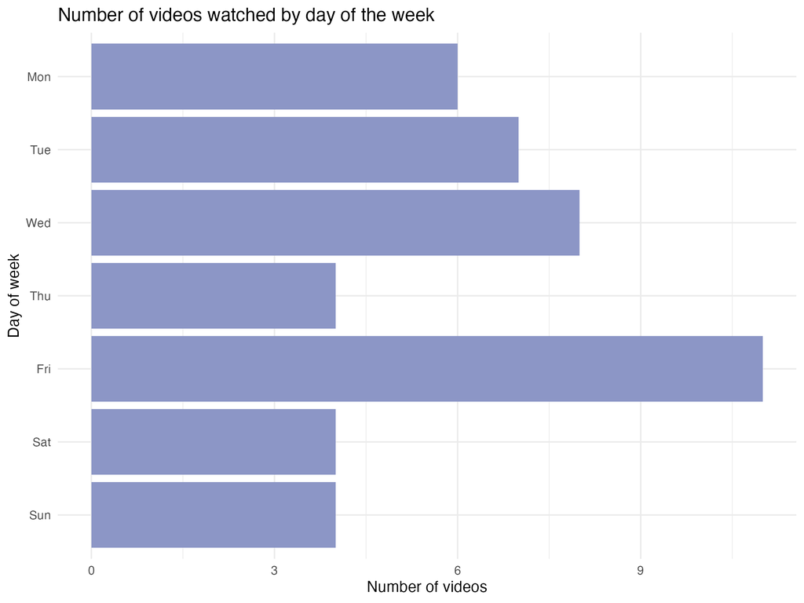

A horizontal bar graph showing the number of videos viewed on each day of the week. It shows that Friday is the day with the most videos watched. Thursday, Saturday and Sunday are tied for least videos watched.

Friday stands out as the most popular watch day (TGIF, I guess). It’s interesting that less videos are watched on the weekend. This could be because I (as the person filling out the data collection form), normally work on Saturdays and use Sundays as a study day. Fridays and Wednesdays are my typical days off.

## YouTube videos can vary greatly in length with some being longer than feature length films. Is there a correlation with video length and views though?

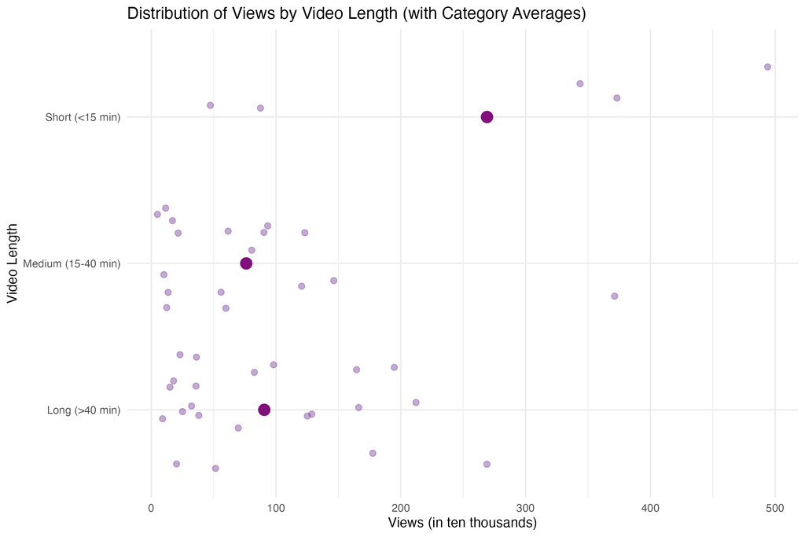

Interesting. It seems that there us not much difference in views between medium and long videos, with their averages being very close to each other. The average views for short videos sits far higher though. I would guess that this could be because shorter videos are more attractive for a shorter attention span or encourage rewatching. Music videos, which tend to get millions of views, would also fall into this category.

## What about another angle of the similar variables. Let’s look at whether video duration impacts video views.

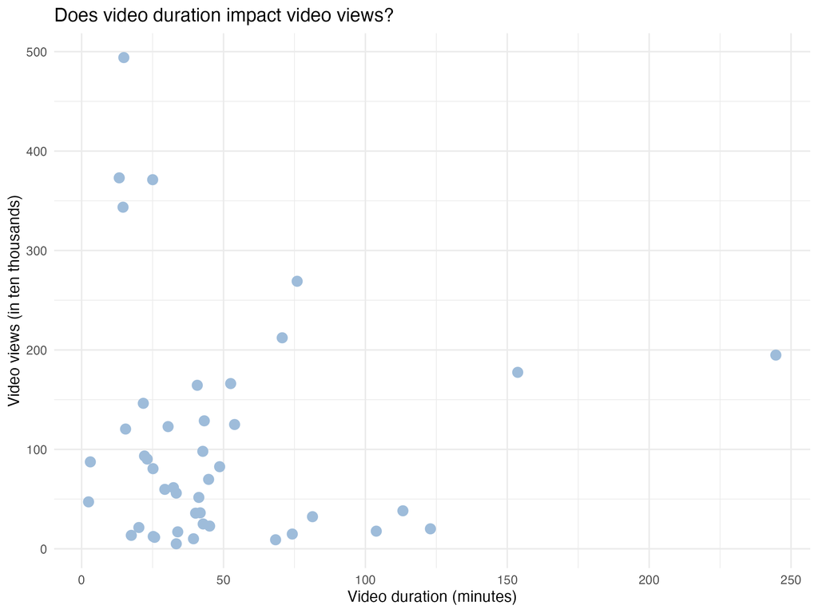

There does not seem to be a strong correlation here. There is a slight positive correlelation between shorter videos and higher views but there are many outliers where long videos have also received many views.

## Let’s pivot now to something completely different. Some YouTube videos fail to hold attention the whole way through. Could the number of words in the title have something to do with it?

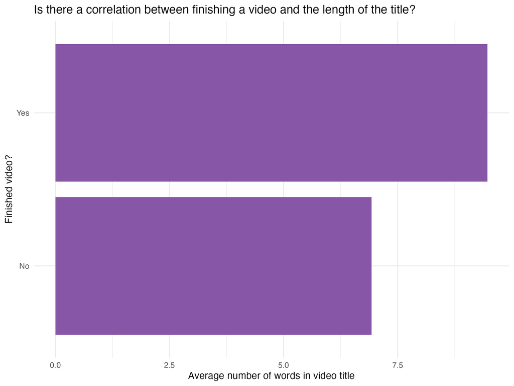

Cool! It seems like videos with more words in their title may be more engaging to me. I wonder why that could be.

## Finally, let’s look at the top 5 channels by their total likes.

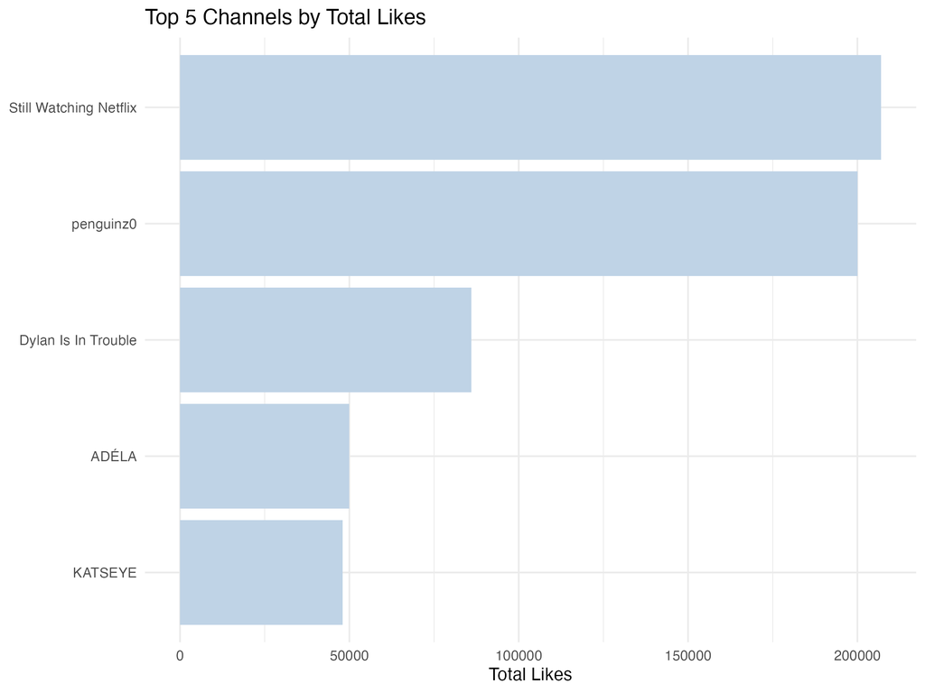

This graph needs to be examined a little closer. It could be that these channels all receive a lot of likes on their videos, or it could be that these channels were the most frequently watched, and therefore had more total likes than others. Interesting nevertheless.

Thanks for reading my visual data story!